# Checking the dashboard data supplied by NE

August 28, 2019

```r
library(tidyverse)
knitr::opts_chunk$set(comment = NA)
```

## Overview

Discovered some problems with the NE summary data:

- participants missing for “all_sports” group
- churn definition needs to be slightly adjusted (e.g., churn in 2018 reflects the % of 2017 license holders who don’t hold a license in 2018)
- age breakouts which sum to a greater number than overall participants & recruits
- are hunter participant counts on the high side?
  - I ask based on a comparison to certified hunter numbers (which admittedly might not be that reliable) https://wsfrprograms.fws.gov/Subpages/LicenseInfo/HuntingLicCertHistory20042015.pdf

## Load

```r
f <- "../../data/NE/southwick.csv"
x1 <- read_csv(f, n_max = 576)

# there is a segment-category mixup at observation 577
cols <- c("timeframe", "group", "category", "segment", "year", "metric", "value")
x2 <- read_csv(f, cols, skip = 577)
x <- bind_rows(x1, x2)

# some small formatting adjustments
x <- x %>% mutate(
    group = ifelse(group == "all", "all_sports", group),
    segment = ifelse(segment == "ageGroup", "age", segment),
    segment = ifelse(segment == "resident", "residency", segment)
)

# Southwick will estimate part. rate for consistency across states
x <- filter(x, metric != "participation rate")

# dropping the gender-gender rows
drop <- filter(x, category == "gender", segment == "gender")
x <- anti_join(x, drop)

glimpse(x)
```

```
Observations: 540
Variables: 7
$ timeframe <chr> "full-year", "full-year", "full-year", "full-year", ...
$ group     <chr> "fish", "fish", "fish", "fish", "fish", "fish", "fis...
$ segment   <chr> "all", "all", "all", "all", "all", "all", "all", "al...
$ category  <chr> "all", "all", "all", "all", "all", "all", "all", "al...
$ year      <int> 2010, 2011, 2012, 2013, 2014, 2015, 2016, 2017, 2018...
$ metric    <chr> "participants", "participants", "participants", "par...
$ value     <dbl> 161429, 156011, 175515, 169158, 167281, 169157, 1732...
```

## Check Completeness

No participant measures included for “all_sports”

```r
count(x, group, metric) %>% spread(metric, n)
```

```
# A tibble: 3 x 4
  group      churn participants recruits
  <chr>      <int>        <int>    <int>
1 all_sports    80           NA       40
2 fish          80           90       40
3 hunt          80           90       40
```

Churn is missing for 2018: This actually does make sense, but we define churn slightly differently (churn in 2018 should reflect the % of 2017 license holders who didn’t hold a license in 2018).

```r
count(x, metric, year) %>% spread(year, n)
```

```
# A tibble: 3 x 10
  metric    `2010` `2011` `2012` `2013` `2014` `2015` `2016` `2017` `2018`
  <chr>      <int>  <int>  <int>  <int>  <int>  <int>  <int>  <int>  <int>
1 churn         30     30     30     30     30     30     30     30     NA
2 particip~     20     20     20     20     20     20     20     20     20
3 recruits      NA     NA     NA     NA     NA     30     30     30     30
```

All good here

```r
count(x, segment, category)
```

```
# A tibble: 10 x 3
   segment   category         n
   <chr>     <chr>        <int>
 1 age       18-24           54
 2 age       25-34           54
 3 age       35-44           54
 4 age       45-54           54
 5 age       55-64           54
 6 all       all             54
 7 gender    Female          54
 8 gender    Male            54
 9 residency Non-resident    54
10 residency Resident        54
```

## Check Total Values

The hunting participant totals diverge from USFWS certified numbers. From https://wsfrprograms.fws.gov/Subpages/LicenseInfo/LicenseIndex.htm:

- Licensed Hunters in 2015: 176K (numbers here seem high)
- Licensed Anglers in 2015: 224K (probably jives once youths/seniors are excluded)

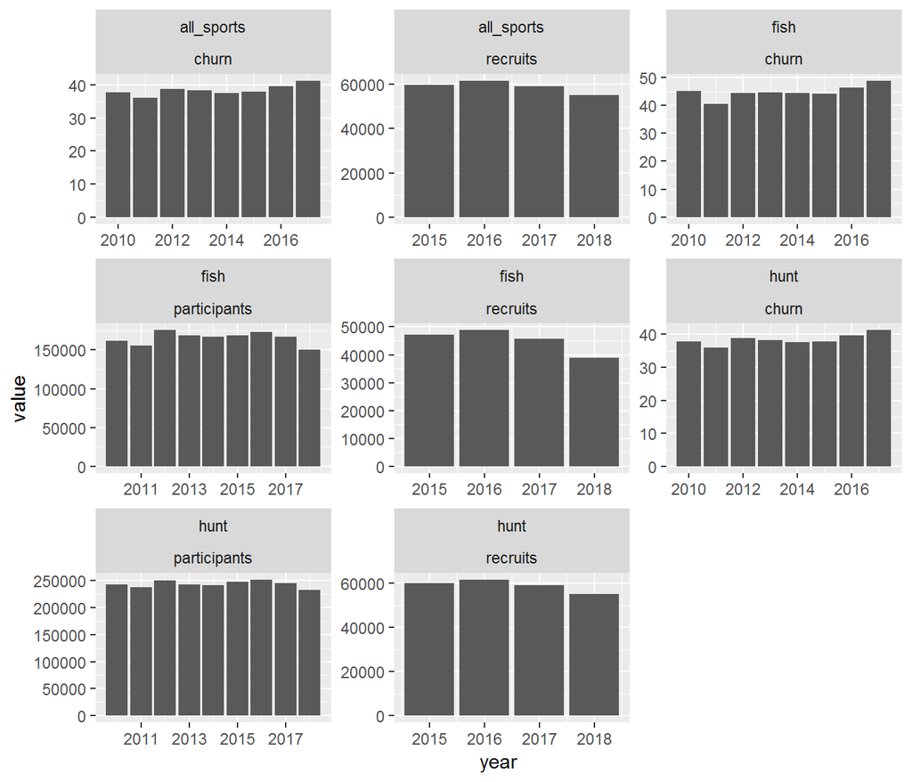

```r
filter(x, segment == "all") %>%
    select(group, year, metric, value) %>%
    ggplot(aes(year, value)) +
    geom_col() +
    facet_wrap(group ~ metric, scales = "free")
```

## Check Segment Sums

The by-age recruits/participants sum to a greater number than the overall recruits/participants in some cases.

```r
tot <- filter(x, segment == "all", metric != "churn") %>%
    select(group, year, metric, value)

seg <- filter(x, segment != "all", metric != "churn") %>%
    group_by(group, year, metric, segment) %>%
    summarise(value.seg = sum(value))

full_join(tot, seg) %>%
    mutate(pct_diff = (value.seg - value) / value * 100) %>%
    filter(abs(pct_diff) > 0.01) %>%
    knitr::kable()
```

| group | year | metric | value | segment | value.seg | pct_diff |
| --- | --- | --- | --- | --- | --- | --- |
| fish | 2010 | participants | 161429 | age | 161495 | 0.0408848 |
| fish | 2011 | participants | 156011 | age | 156077 | 0.0423047 |
| fish | 2012 | participants | 175515 | age | 175585 | 0.0398826 |
| fish | 2013 | participants | 169158 | age | 169207 | 0.0289670 |
| fish | 2014 | participants | 167281 | age | 167351 | 0.0418458 |
| fish | 2015 | participants | 169157 | age | 169226 | 0.0407905 |
| fish | 2016 | participants | 173203 | age | 173289 | 0.0496527 |
| fish | 2017 | participants | 167032 | age | 167106 | 0.0443029 |
| fish | 2018 | participants | 150338 | age | 150388 | 0.0332584 |
| hunt | 2010 | participants | 242255 | age | 245249 | 1.2358878 |
| hunt | 2011 | participants | 237258 | age | 240007 | 1.1586543 |
| hunt | 2012 | participants | 249815 | age | 252477 | 1.0655885 |
| hunt | 2013 | participants | 241850 | age | 244324 | 1.0229481 |
| hunt | 2014 | participants | 240385 | age | 242951 | 1.0674543 |
| hunt | 2015 | participants | 246659 | age | 249448 | 1.1307108 |
| hunt | 2016 | participants | 251363 | age | 254158 | 1.1119377 |
| hunt | 2017 | participants | 245218 | age | 247682 | 1.0048202 |
| hunt | 2018 | participants | 232584 | age | 235014 | 1.0447838 |
| all_sports | 2015 | recruits | 59908 | age | 83287 | 39.0248381 |
| all_sports | 2016 | recruits | 61649 | age | 85214 | 38.2244643 |
| all_sports | 2017 | recruits | 59037 | age | 81980 | 38.8620695 |
| all_sports | 2018 | recruits | 55146 | age | 76571 | 38.8514126 |
| fish | 2015 | recruits | 47179 | age | 62888 | 33.2965938 |
| fish | 2016 | recruits | 48816 | age | 65418 | 34.0093412 |
| fish | 2017 | recruits | 45730 | age | 61994 | 35.5652744 |
| fish | 2018 | recruits | 38935 | age | 53612 | 37.6961603 |
| hunt | 2015 | recruits | 59909 | age | 83288 | 39.0241867 |
| hunt | 2016 | recruits | 61650 | age | 85215 | 38.2238443 |
| hunt | 2017 | recruits | 59036 | age | 81978 | 38.8610339 |
| hunt | 2018 | recruits | 55145 | age | 76570 | 38.8521171 |

## Check By-Segment Values

I also looked at some segment-specific graphical summaries (not run here); I didn’t see anything unusual.

```r
filter(x, segment == "gender") %>%
    ggplot(aes(year, value, fill = category)) +
    geom_col(position = position_dodge()) +
    facet_wrap(group ~ metric, scales = "free")

filter(x, segment == "residency") %>%
    ggplot(aes(year, value, fill = category)) +
    geom_col(position = position_dodge()) +
    facet_wrap(group ~ metric, scales = "free")

filter(x, segment == "age", metric == "participants") %>%
    ggplot(aes(year, value)) +
    geom_col() +
    facet_grid(group ~ category, scales = "free")

filter(x, segment == "age", metric == "recruits") %>%
    ggplot(aes(year, value)) +
    geom_col() +
    facet_grid(group ~ category, scales = "free")

filter(x, segment == "age", metric == "churn") %>%
    ggplot(aes(year, value)) +
    geom_col() +
    facet_grid(group ~ category, scales = "free")
```